# Visualizing predictor effects using accumulated local effect (ALE) plots

Identifying ‘hot spots’ of car crashes in NYC

Python

Data Science Applications

Data Visualization

Author

Gio Circo, Ph.D.

Published

February 20, 2026

## Improving Model Explainability with ALE

One of the major drawbacks with many machine learning models is that explainability is often challenging. Unlike methods that rely on more conventional statistical inference, machine learning models are often opaque on *why* a certain prediction was made. Consider the example of a random forest. A specific prediction derives from the aggregation over many shallow decision trees, so understanding how a prediction varies *on average* is much less straightforward than a linear model.

ALE, or accumulated local effects, are a method to help decompose the effect of a predictor feature on the subsequent prediction. In a more conventional setup you can consider these very similar to a partial effects plot. The end goal here is to isolate how the effect of the predictor changes, on average, over different input values (e.g. does it monotonically increase? Does it decay?).

To show this, I put together another example by using `gridpred` to build out a highly simplistic prediction model for car accidents. If you want a more step-by-step process of how `GridPred` works, can you go to the first blog post on it [here](https://gmcirco.github.io/blog/posts/gridpred-demo/gridpred.html).

### Pulling crash data from the NYC data portal

For this example I rely on [car accident report data](https://data.cityofnewyork.us/Public-Safety/Motor-Vehicle-Collisions-Crashes/h9gi-nx95/about_data) from the New York City Open Data portal. For predictor features, I also extract the location of pedestrian crossings and bus stops. The assumption here is these locations are more prone to accidents with cars suddenly stopping or moving around busses.

```python
import os
from datetime import datetime, timedelta

import geopandas as gpd
import matplotlib.pyplot as plt
import pandas as pd
import seaborn as sns
import numpy as np
import skexplain
from dotenv import load_dotenv
from shapely.geometry import shape
from sodapy import Socrata

from gridpred.evaluate.metrics import evaluate, pai, pei, rri
from gridpred.model.random_forest import RandomForestGridPred
from gridpred.plotting import visualize_predictions
from gridpred.prediction import GridPred

# Set up client
load_dotenv()
APP_TOKEN = os.getenv("APP_TOKEN")
client = Socrata("data.cityofnewyork.us", APP_TOKEN)

# Set plotting theme
sns.set_theme(context='notebook', style="ticks", palette='deep', font='sans-serif', font_scale=1, color_codes=True, rc=None)

# local  funcs for data
def get_date_lookback(lookback_days=14):
    "Retrieve a date from a number of lookback days"
    current_date = datetime.today()
    lookback_date = current_date - timedelta(days=lookback_days)

    return lookback_date.strftime("%Y-%m-%d")

def get_features(borough):
    "Retrieve all predictor features"

    # bus stop point locations
    bus_stops = pd.DataFrame(client.get(
        "t4f2-8md7",
        select="'BusStop' AS type,Longitude, Latitude",
        where=f"boro_name = '{borough.capitalize()}'",
        limit=1000,
    ))

    # pedesterian crossings point locations
    ped_xing = pd.DataFrame(client.get(
        "xc4v-ntf4",
        select="'PedXing' AS type, long AS Longitude, lat AS Latitude",
        limit=7000,
    ))
    return pd.concat([bus_stops, ped_xing])

def get_study_region_spatial(borough, espg="4326"):
    "Retrieve a boro boundaries, parse as a geopandas object"
    data = client.get("gthc-hcne",
           select="*",
           where=f"boroname = '{borough.capitalize()}'")

    # parse api response to geopandas
    rows = []
    for r in data:
        rows.append({
            **{k: v for k, v in r.items() if k != "the_geom"},
            "geometry": shape(r["the_geom"])
        })

    return(gpd.GeoDataFrame(rows, crs=f"EPSG:{espg}"))

# -- Workflow stuff --- #

#  define a borough and a lookback period
BOROUGH = "BROOKLYN"
LOOKBACK_DAYS = 28*4

# retrieve point locations of crashes within date range
date = get_date_lookback(LOOKBACK_DAYS)

results = client.get("h9gi-nx95",
                     select="crash_date, borough, latitude, longitude",
                     where=f"crash_date >= '{date}' AND borough = '{BOROUGH}' AND latitude != 0 AND longitude != 0",
                     limit=10000)
results_df = pd.DataFrame.from_records(results)

# point features
feat_df = get_features(BOROUGH)

# region spatial
boro_region = get_study_region_spatial(BOROUGH)

# create a dataframe where we define time periods
# model uses t-1 for training
# t=0 for validation

# Parse datetime
results_df["crash_date"] = pd.to_datetime(results_df["crash_date"])

# Get the oldest date
min_date = results_df["crash_date"].min()

# Compute 2-week periods forward in time
results_df["timevar"] = (
    (results_df["crash_date"] - min_date).dt.days // 14
) + 1
```

After setting up the data we just define the input variables, feature names, and create the `GridPred` object. Below, the workflow runs a test model using the first 6 weeks of data as predictors, week 7 as the outcome, and week 8 as the validation set. We get the performance metrics and then run the model again on the FULL set (weeks 1-7 as predictors, week 8 as outcome) and get predictions for the next week.

```python
# define variable names
time_var = "timevar"
features_var = "type"

# spatial projections
# includes the coordinate reference system of the input crime data
# as well as a desired projection for all spatial objects
input_crime_crs = 4326
projected_crs = 3857

# size of the grid to use (in units based on projection)
grid_size = 300

# This initalizes the GridPred class with the specified data
gridpred = GridPred(
    input_crime_data=results_df,
    input_features_data=feat_df,
    features_names_variable=features_var,
    crime_time_variable=time_var,
    input_study_region=boro_region,
    input_crs=input_crime_crs,
)

# This generates the input to the regression model
gridpred.prepare_data(
    grid_cell_size=grid_size,
    do_projection=True,
    projected_crs=3857
)
# very basic demo model workflow
# can replace with xgboost or whatever model
X = gridpred.X
y = gridpred.y

rf = RandomForestGridPred(
    n_estimators=1000, criterion="poisson", random_state=42
)
rf.fit(X, y)
y_pred = rf.predict(X)

# check eval metrics on test then rerun
region_grid = gridpred.region_grid
METRICS = {'PAI': pai, 'PEI': pei, 'RRI': rri}

print(
   evaluate(
        y_true=gridpred.eval,
        y_pred=y_pred,
        metrics=METRICS,
        region_grid=region_grid,
        round_digits=2
    )
)

# now next-weeks prediction
Xfinal = gridpred.X_final
yfinal = gridpred.y_final

rf_final = RandomForestGridPred(
    n_estimators=1000, criterion="poisson", random_state=42
)
rf_final.fit(Xfinal, yfinal)
y_pred_final = rf_final.predict(Xfinal)
```

```
{'PAI': 3.84, 'PEI': 0.25, 'RRI': 4.3}
```

[output not shown]

The map below shows the predicted hot spots of car crashes. Primarily, these are near the main highways around the Brooklyn and Williamsburg bridges.

[figure not shown]

Predicted intensity of auto accidents for week of 2026-02-23. Gridded squares are 300x300 foot zones.

## Accumulated Local Effects

To start, I think reading through Christoph Molnar’s free book [Interpretable Machine Learning](https://christophm.github.io/interpretable-ml-book/ale.html) is an essential starting point (Molnar 2020). To reiterate (without getting too much into the weeds) our goal is to identify differences in predictions conditional on a small “window” around the feature set. This second part is important, because ALE plots are constrained to observed, local differences in predictions. This avoids getting predictions from combinations of features that would never exist (one of the examples Molnar gives is an improbable house prediction for a 30 square meter house containing 10 rooms). Because we accumulate predictions over small regions of the observed feature space, we avoid a lot of the issues described above.

For a quick example, we can look at the the most important features in our Random Forest model. We see that distance to the nearest `PedXing` and `BusStop` are the top two features. Now, one question might be “how close to the nearest pedestrian crossing or bus stop is car accident risk increased?” This is actually a plausible question, as it might affect where signs are placed or inform environmental design elements.

```python
importances = pd.Series(rf_final.get_feature_importances(), index=Xfinal.columns)
print(importances.sort_values(ascending=False))
```

```
PedXing     0.274759
BusStop     0.177642
y           0.129083
x           0.108699
events_6    0.056754
events_4    0.046830
events_3    0.046804
events_2    0.043932
events_7    0.041374
events_5    0.041195
events_1    0.032930
dtype: float64
```

```python
def unpack_feature(ds, feat_name):
    """
    Extracts the bin values and ALE values for a specific feature.
    """

    # get the bin values and ale calculations for selected feature
    values_bin = ds[f"{feat_name}__bin_values"].values
    values_ale = ds[f"{feat_name}__name__ale"].values

    return values_bin, values_ale

def unpack_feature_2d(ds, feat_x, feat_y):
    """
    Extracts bin values and ALE values for a 2D feature interaction.
    """

    # bin values
    x_bin = ds[f"{feat_x}__bin_values"].values
    y_bin = ds[f"{feat_y}__bin_values"].values

    # handle possible ordering of feature names
    key1 = f"{feat_x}__{feat_y}__name__ale"
    key2 = f"{feat_y}__{feat_x}__name__ale"

    if key1 in ds:
        ale_vals = ds[key1].values
    elif key2 in ds:
        ale_vals = ds[key2].values
    else:
        raise KeyError(f"No 2D ALE found for {feat_x}, {feat_y}")

    return x_bin, y_bin, ale_vals

def plot_feature_ale_1d(ds, feature, xlim=None, ylim=None):

    # unpack feature data
    values_bin, values_ale = unpack_feature(ds, feature)

    # aggregate across bootstrap iterations
    val_min = values_ale.min(axis=0)
    val_avg = values_ale.mean(axis=0)
    val_max = values_ale.max(axis=0)

    # plot
    plt.figure(figsize=(5, 4))
    plt.fill_between(
        x=values_bin,
        y1=val_min,
        y2=val_max,
        alpha=0.2,
        color='#0077BB'
    )
    sns.lineplot(
        x=values_bin,
        y=val_avg,
        color='#0077BB',
        label='Mean ALE'
    )
    plt.axhline(y=0, color='#CC3311', linestyle='--', linewidth=1)

    plt.title(f"1D ALE Plot: {feature}")
    plt.xlabel(f"{feature} Values")
    plt.ylabel("ALE Effect")

    # axis constraints
    if xlim is not None:
        plt.xlim(xlim)

    if ylim is not None:
        plt.ylim(ylim)

    sns.despine()
    plt.tight_layout()
    plt.show()

def plot_feature_ale_2d(
    ds,
    feat_x,
    feat_y,
    xlim=None,
    ylim=None,
    clim=None  # (vmin, vmax) for color scaling
):

    # unpack
    x_bin, y_bin, ale_vals = unpack_feature_2d(ds, feat_x, feat_y)

    # aggregate across bootstraps
    ale_mean = ale_vals.mean(axis=0)

    # meshgrid
    X, Y = np.meshgrid(x_bin, y_bin, indexing="ij")

    # symmetric scaling by default
    if clim is None:
        vmax = np.abs(ale_mean).max()
        vmin = -vmax
    else:
        vmin, vmax = clim

    plt.figure(figsize=(6, 5))
    contour = plt.contourf(
        X,
        Y,
        ale_mean,
        levels=20,
        cmap="RdBu_r",
        vmin=vmin,
        vmax=vmax
    )

    plt.colorbar(contour, label="ALE Effect")

    plt.title(f"2D ALE Plot: {feat_x} × {feat_y}")
    plt.xlabel(feat_x)
    plt.ylabel(feat_y)

    # axis constraints
    if xlim is not None:
        plt.xlim(xlim)

    if ylim is not None:
        plt.ylim(ylim)

    sns.despine()
    plt.tight_layout()
    plt.show()
```

Below we get the 1D ALE plots for two of the features: distance to bus stops and pedestrian crossings. We limit the predictions to within the first 1000 feet, since that is well within the area of interest. The ALE effect is the centered effect, so the y-axis is based on increases or decreases from the mean prediction.

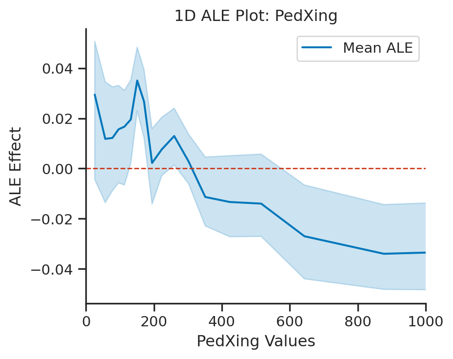

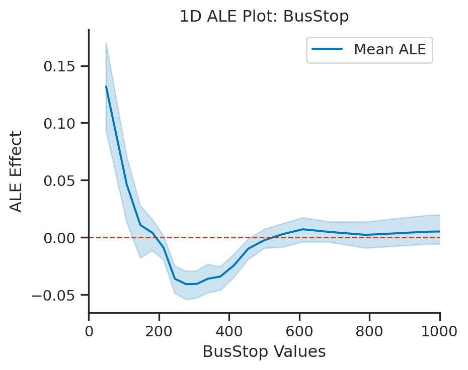

```python
plot_feature_ale_1d(ale_1d_ds, 'PedXing',xlim=(0,1000))
plot_feature_ale_1d(ale_1d_ds, 'BusStop',xlim=(0,1000))
```

We can also examine the interaction between both features using a contour plot. Below, we see an interesting interaction where areas very close to a bus stop AND pedestrian crossing have lower risk together. However, the risk of accidents is increased in distances exclusively near bus stops OR pedestrian crossings. Again, some of these results are probably structural elements related to how the road network is set up in different neighborhoods.

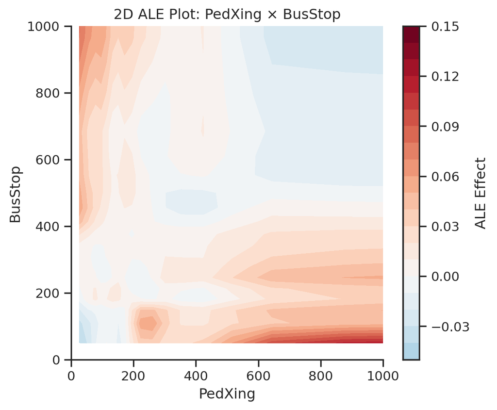

```python
plot_feature_ale_2d(ale_2d_ds, 'PedXing','BusStop',xlim=(0,1000),ylim=(0,1000))
```

## References

Molnar, Christoph. 2020. *Interpretable Machine Learning*. Lulu. com.